# Risk Factor Analysis

## Outcome Variable

**Outcome Variable:** stunted

## Predictor Variables

**Intervention Variable:** hfoodsec

**Adjustment Set:**

- arm
- sex
- W_mage
- meducyrs
- feducyrs
- hhwealth_quart
- vagbrth
- W_nrooms
- W_nchldlt5
- brthmon
- W_parity
- impfloor
- impsan
- safeh20
- delta_W_mage
- delta_meducyrs
- delta_feducyrs
- delta_hhwealth_quart
- delta_vagbrth
- delta_W_nrooms
- delta_W_nchldlt5
- delta_brthmon
- delta_W_parity
- delta_impfloor
- delta_impsan
- delta_safeh20

## Stratifying Variables

The analysis was stratified on these variable(s):

- agecat
- studyid
- country

## Data Summary

| agecat | studyid | country | hfoodsec | stunted | n_cell | n |
| --- | --- | --- | --- | --- | --- | --- |
| Birth | GMS-Nepal | NEPAL | Food Secure | 0 | 401 | 672 |
| Birth | GMS-Nepal | NEPAL | Food Secure | 1 | 76 | 672 |
| Birth | GMS-Nepal | NEPAL | Mildly Food Insecure | 0 | 86 | 672 |
| Birth | GMS-Nepal | NEPAL | Mildly Food Insecure | 1 | 20 | 672 |
| Birth | GMS-Nepal | NEPAL | Food Insecure | 0 | 69 | 672 |
| Birth | GMS-Nepal | NEPAL | Food Insecure | 1 | 20 | 672 |
| Birth | JiVitA-3 | BANGLADESH | Food Secure | 0 | 4894 | 14364 |
| Birth | JiVitA-3 | BANGLADESH | Food Secure | 1 | 2057 | 14364 |
| Birth | JiVitA-3 | BANGLADESH | Mildly Food Insecure | 0 | 3303 | 14364 |
| Birth | JiVitA-3 | BANGLADESH | Mildly Food Insecure | 1 | 1574 | 14364 |
| Birth | JiVitA-3 | BANGLADESH | Food Insecure | 0 | 1696 | 14364 |
| Birth | JiVitA-3 | BANGLADESH | Food Insecure | 1 | 840 | 14364 |
| Birth | JiVitA-4 | BANGLADESH | Food Secure | 0 | 978 | 2810 |
| Birth | JiVitA-4 | BANGLADESH | Food Secure | 1 | 455 | 2810 |
| Birth | JiVitA-4 | BANGLADESH | Mildly Food Insecure | 0 | 722 | 2810 |
| Birth | JiVitA-4 | BANGLADESH | Mildly Food Insecure | 1 | 296 | 2810 |
| Birth | JiVitA-4 | BANGLADESH | Food Insecure | 0 | 253 | 2810 |
| Birth | JiVitA-4 | BANGLADESH | Food Insecure | 1 | 106 | 2810 |
| Birth | MAL-ED | BANGLADESH | Food Secure | 0 | 121 | 172 |
| Birth | MAL-ED | BANGLADESH | Food Secure | 1 | 23 | 172 |
| Birth | MAL-ED | BANGLADESH | Mildly Food Insecure | 0 | 3 | 172 |
| Birth | MAL-ED | BANGLADESH | Mildly Food Insecure | 1 | 1 | 172 |
| Birth | MAL-ED | BANGLADESH | Food Insecure | 0 | 19 | 172 |
| Birth | MAL-ED | BANGLADESH | Food Insecure | 1 | 5 | 172 |
| Birth | MAL-ED | BRAZIL | Food Secure | 0 | 0 | 28 |
| Birth | MAL-ED | BRAZIL | Food Secure | 1 | 0 | 28 |
| Birth | MAL-ED | BRAZIL | Mildly Food Insecure | 0 | 3 | 28 |
| Birth | MAL-ED | BRAZIL | Mildly Food Insecure | 1 | 1 | 28 |
| Birth | MAL-ED | BRAZIL | Food Insecure | 0 | 20 | 28 |
| Birth | MAL-ED | BRAZIL | Food Insecure | 1 | 4 | 28 |

[output cut: 168 more lines]

The following strata were considered:

- agecat: 24 months, studyid: GMS-Nepal, country: NEPAL
- agecat: 24 months, studyid: JiVitA-3, country: BANGLADESH
- agecat: 24 months, studyid: JiVitA-4, country: BANGLADESH
- agecat: 24 months, studyid: MAL-ED, country: BANGLADESH
- agecat: 24 months, studyid: MAL-ED, country: BRAZIL
- agecat: 24 months, studyid: MAL-ED, country: INDIA
- agecat: 24 months, studyid: MAL-ED, country: NEPAL
- agecat: 24 months, studyid: MAL-ED, country: PERU
- agecat: 24 months, studyid: MAL-ED, country: SOUTH AFRICA
- agecat: 24 months, studyid: NIH-Birth, country: BANGLADESH
- agecat: 24 months, studyid: NIH-Crypto, country: BANGLADESH
- agecat: 6 months, studyid: GMS-Nepal, country: NEPAL
- agecat: 6 months, studyid: JiVitA-3, country: BANGLADESH
- agecat: 6 months, studyid: JiVitA-4, country: BANGLADESH
- agecat: 6 months, studyid: MAL-ED, country: BANGLADESH
- agecat: 6 months, studyid: MAL-ED, country: BRAZIL
- agecat: 6 months, studyid: MAL-ED, country: INDIA
- agecat: 6 months, studyid: MAL-ED, country: NEPAL
- agecat: 6 months, studyid: MAL-ED, country: PERU
- agecat: 6 months, studyid: MAL-ED, country: SOUTH AFRICA
- agecat: 6 months, studyid: NIH-Birth, country: BANGLADESH
- agecat: 6 months, studyid: NIH-Crypto, country: BANGLADESH
- agecat: Birth, studyid: GMS-Nepal, country: NEPAL
- agecat: Birth, studyid: JiVitA-3, country: BANGLADESH
- agecat: Birth, studyid: JiVitA-4, country: BANGLADESH
- agecat: Birth, studyid: MAL-ED, country: BANGLADESH
- agecat: Birth, studyid: MAL-ED, country: BRAZIL
- agecat: Birth, studyid: MAL-ED, country: INDIA
- agecat: Birth, studyid: MAL-ED, country: NEPAL
- agecat: Birth, studyid: MAL-ED, country: PERU
- agecat: Birth, studyid: MAL-ED, country: SOUTH AFRICA
- agecat: Birth, studyid: NIH-Birth, country: BANGLADESH
- agecat: Birth, studyid: NIH-Crypto, country: BANGLADESH

### Dropped Strata

Some strata were dropped due to rare outcomes:

- agecat: Birth, studyid: MAL-ED, country: BANGLADESH
- agecat: Birth, studyid: MAL-ED, country: BRAZIL
- agecat: Birth, studyid: MAL-ED, country: INDIA
- agecat: Birth, studyid: MAL-ED, country: NEPAL
- agecat: Birth, studyid: MAL-ED, country: PERU
- agecat: Birth, studyid: MAL-ED, country: SOUTH AFRICA
- agecat: 6 months, studyid: MAL-ED, country: BANGLADESH
- agecat: 6 months, studyid: MAL-ED, country: BRAZIL
- agecat: 6 months, studyid: MAL-ED, country: INDIA
- agecat: 6 months, studyid: MAL-ED, country: NEPAL
- agecat: 6 months, studyid: MAL-ED, country: SOUTH AFRICA
- agecat: 24 months, studyid: MAL-ED, country: BANGLADESH
- agecat: 24 months, studyid: MAL-ED, country: BRAZIL
- agecat: 24 months, studyid: MAL-ED, country: INDIA
- agecat: 24 months, studyid: MAL-ED, country: NEPAL

## Methods Detail

We’re interested in the causal parameters $E[Y_a]$ for all values of $a \in \mathcal{A}$. These parameters represent the mean outcome if, possibly contrary to fact, we intervened to set all units to have $A=a$. Under the randomization and positivity assumptions, these are identified by the statistical parameters $\psi_a=E_W[E_{Y|A,W}(Y|A=a,W)]$. In addition, we’re interested in the mean of $Y$, $E[Y]$ under no intervention (the observed mean). We will estimate these parameters by using SuperLearner to fit the relevant likelihood factors – $E_{Y|A,W}(Y|A=a,W)$ and $p(A=a|W)$, and then updating our likelihood fit using a joint TMLE.

For unadjusted analyses ($W=\{\}$), initial likelihoods were estimated using Lrnr_glm to estimate the simple $E(Y|A)$ and Lrnr_mean to estimate $p(A)$. For adjusted analyses, a small library containing Lrnr_glmnet, Lrnr_xgboost, and Lrnr_mean was used.

Having estimated these parameters, we will then use the delta method to estimate relative risks and attributable risks relative to a prespecified baseline level of $A$.

# Results Detail

## Results Plots

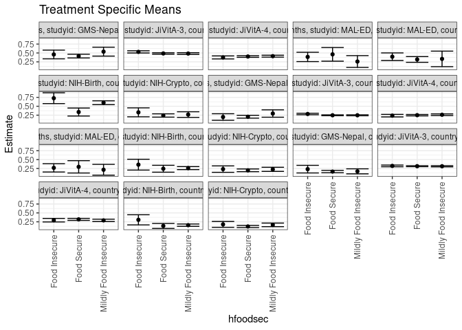

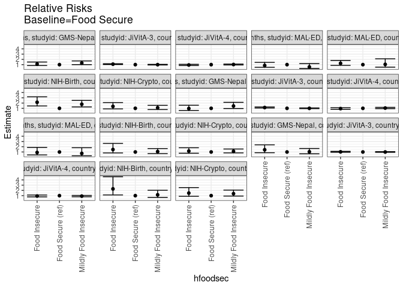

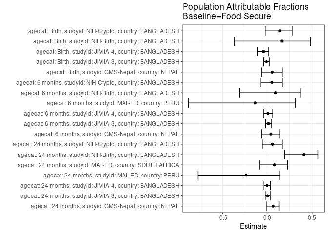

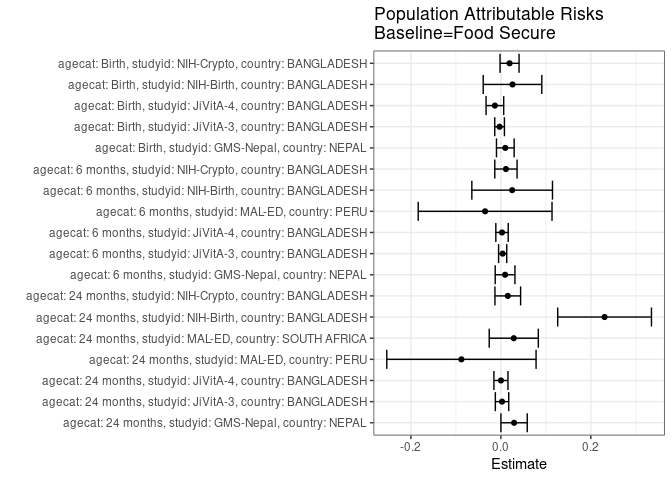

## Results Table

### Parameter: TSM

| agecat | studyid | country | intervention_level | baseline_level | estimate | ci_lower | ci_upper |
| --- | --- | --- | --- | --- | --- | --- | --- |
| Birth | GMS-Nepal | NEPAL | Food Secure | NA | 0.1627557 | 0.1290968 | 0.1964145 |
| Birth | GMS-Nepal | NEPAL | Mildly Food Insecure | NA | 0.1696462 | 0.0989899 | 0.2403026 |
| Birth | GMS-Nepal | NEPAL | Food Insecure | NA | 0.2312235 | 0.1246593 | 0.3377876 |
| Birth | JiVitA-3 | BANGLADESH | Food Secure | NA | 0.3141443 | 0.3006825 | 0.3276061 |
| Birth | JiVitA-3 | BANGLADESH | Mildly Food Insecure | NA | 0.3128506 | 0.2963117 | 0.3293895 |
| Birth | JiVitA-3 | BANGLADESH | Food Insecure | NA | 0.3224090 | 0.2988144 | 0.3460036 |
| Birth | JiVitA-4 | BANGLADESH | Food Secure | NA | 0.3182981 | 0.2902201 | 0.3463761 |
| Birth | JiVitA-4 | BANGLADESH | Mildly Food Insecure | NA | 0.2897414 | 0.2563296 | 0.3231531 |
| Birth | JiVitA-4 | BANGLADESH | Food Insecure | NA | 0.2952291 | 0.2457437 | 0.3447144 |
| Birth | NIH-Birth | BANGLADESH | Food Secure | NA | 0.1336758 | 0.0642486 | 0.2031029 |
| Birth | NIH-Birth | BANGLADESH | Mildly Food Insecure | NA | 0.1548611 | 0.1223788 | 0.1873434 |
| Birth | NIH-Birth | BANGLADESH | Food Insecure | NA | 0.3056285 | 0.1630712 | 0.4481859 |
| Birth | NIH-Crypto | BANGLADESH | Food Secure | NA | 0.1186778 | 0.0882853 | 0.1490702 |
| Birth | NIH-Crypto | BANGLADESH | Mildly Food Insecure | NA | 0.1635244 | 0.1129858 | 0.2140630 |
| Birth | NIH-Crypto | BANGLADESH | Food Insecure | NA | 0.1769056 | 0.0948060 | 0.2590053 |
| 6 months | GMS-Nepal | NEPAL | Food Secure | NA | 0.2067731 | 0.1666900 | 0.2468562 |
| 6 months | GMS-Nepal | NEPAL | Mildly Food Insecure | NA | 0.2962855 | 0.1924222 | 0.4001488 |
| 6 months | GMS-Nepal | NEPAL | Food Insecure | NA | 0.1981519 | 0.1059620 | 0.2903417 |
| 6 months | JiVitA-3 | BANGLADESH | Food Secure | NA | 0.2474680 | 0.2356244 | 0.2593117 |
| 6 months | JiVitA-3 | BANGLADESH | Mildly Food Insecure | NA | 0.2472197 | 0.2335348 | 0.2609045 |
| 6 months | JiVitA-3 | BANGLADESH | Food Insecure | NA | 0.2833695 | 0.2618546 | 0.3048843 |
| 6 months | JiVitA-4 | BANGLADESH | Food Secure | NA | 0.2503187 | 0.2305378 | 0.2700996 |
| 6 months | JiVitA-4 | BANGLADESH | Mildly Food Insecure | NA | 0.2623967 | 0.2388667 | 0.2859267 |
| 6 months | JiVitA-4 | BANGLADESH | Food Insecure | NA | 0.2364570 | 0.2007192 | 0.2721948 |
| 6 months | MAL-ED | PERU | Food Secure | NA | 0.2962963 | 0.1232791 | 0.4693135 |
| 6 months | MAL-ED | PERU | Mildly Food Insecure | NA | 0.2142857 | 0.0616124 | 0.3669590 |
| 6 months | MAL-ED | PERU | Food Insecure | NA | 0.2678571 | 0.1513457 | 0.3843686 |
| 6 months | NIH-Birth | BANGLADESH | Food Secure | NA | 0.2430705 | 0.1464495 | 0.3396914 |
| 6 months | NIH-Birth | BANGLADESH | Mildly Food Insecure | NA | 0.2607675 | 0.2185094 | 0.3030257 |
| 6 months | NIH-Birth | BANGLADESH | Food Insecure | NA | 0.3571960 | 0.2051680 | 0.5092240 |
| 6 months | NIH-Crypto | BANGLADESH | Food Secure | NA | 0.1985652 | 0.1605749 | 0.2365554 |
| 6 months | NIH-Crypto | BANGLADESH | Mildly Food Insecure | NA | 0.2261899 | 0.1685878 | 0.2837921 |
| 6 months | NIH-Crypto | BANGLADESH | Food Insecure | NA | 0.2324777 | 0.1425670 | 0.3223884 |
| 24 months | GMS-Nepal | NEPAL | Food Secure | NA | 0.4120515 | 0.3595330 | 0.4645700 |
| 24 months | GMS-Nepal | NEPAL | Mildly Food Insecure | NA | 0.5375579 | 0.4121410 | 0.6629749 |
| 24 months | GMS-Nepal | NEPAL | Food Insecure | NA | 0.4579826 | 0.3355578 | 0.5804075 |
| 24 months | JiVitA-3 | BANGLADESH | Food Secure | NA | 0.4864639 | 0.4661976 | 0.5067301 |
| 24 months | JiVitA-3 | BANGLADESH | Mildly Food Insecure | NA | 0.4836347 | 0.4597535 | 0.5075159 |
| 24 months | JiVitA-3 | BANGLADESH | Food Insecure | NA | 0.5305977 | 0.4995830 | 0.5616125 |
| 24 months | JiVitA-4 | BANGLADESH | Food Secure | NA | 0.4008901 | 0.3773595 | 0.4244207 |
| 24 months | JiVitA-4 | BANGLADESH | Mildly Food Insecure | NA | 0.4098963 | 0.3831301 | 0.4366624 |
| 24 months | JiVitA-4 | BANGLADESH | Food Insecure | NA | 0.3749513 | 0.3326015 | 0.4173011 |
| 24 months | MAL-ED | PERU | Food Secure | NA | 0.4615385 | 0.2690159 | 0.6540610 |
| 24 months | MAL-ED | PERU | Mildly Food Insecure | NA | 0.2592593 | 0.0931838 | 0.4253347 |
| 24 months | MAL-ED | PERU | Food Insecure | NA | 0.3888889 | 0.2582528 | 0.5195249 |
| 24 months | MAL-ED | SOUTH AFRICA | Food Secure | NA | 0.3178295 | 0.2373006 | 0.3983583 |
| 24 months | MAL-ED | SOUTH AFRICA | Mildly Food Insecure | NA | 0.3333333 | 0.1150804 | 0.5515863 |
| 24 months | MAL-ED | SOUTH AFRICA | Food Insecure | NA | 0.3950617 | 0.2883657 | 0.5017577 |
| 24 months | NIH-Birth | BANGLADESH | Food Secure | NA | 0.3382353 | 0.2256552 | 0.4508154 |
| 24 months | NIH-Birth | BANGLADESH | Mildly Food Insecure | NA | 0.6006098 | 0.5475442 | 0.6536753 |
| 24 months | NIH-Birth | BANGLADESH | Food Insecure | NA | 0.7272727 | 0.5751441 | 0.8794013 |
| 24 months | NIH-Crypto | BANGLADESH | Food Secure | NA | 0.2414766 | 0.1952352 | 0.2877179 |
| 24 months | NIH-Crypto | BANGLADESH | Mildly Food Insecure | NA | 0.2668063 | 0.1876525 | 0.3459601 |
| 24 months | NIH-Crypto | BANGLADESH | Food Insecure | NA | 0.3294848 | 0.2040631 | 0.4549065 |

### Parameter: E(Y)

| agecat | studyid | country | intervention_level | baseline_level | estimate | ci_lower | ci_upper |
| --- | --- | --- | --- | --- | --- | --- | --- |
| Birth | GMS-Nepal | NEPAL | NA | NA | 0.1726190 | 0.1440245 | 0.2012136 |
| Birth | JiVitA-3 | BANGLADESH | NA | NA | 0.3112643 | 0.3026111 | 0.3199174 |
| Birth | JiVitA-4 | BANGLADESH | NA | NA | 0.3049822 | 0.2848489 | 0.3251155 |
| Birth | NIH-Birth | BANGLADESH | NA | NA | 0.1595395 | 0.1304091 | 0.1886699 |
| Birth | NIH-Crypto | BANGLADESH | NA | NA | 0.1379781 | 0.1129774 | 0.1629789 |
| 6 months | GMS-Nepal | NEPAL | NA | NA | 0.2161172 | 0.1815615 | 0.2506729 |
| 6 months | JiVitA-3 | BANGLADESH | NA | NA | 0.2514442 | 0.2432971 | 0.2595914 |
| 6 months | JiVitA-4 | BANGLADESH | NA | NA | 0.2528688 | 0.2386164 | 0.2671211 |
| 6 months | MAL-ED | PERU | NA | NA | 0.2612613 | 0.1791629 | 0.3433597 |
| 6 months | NIH-Birth | BANGLADESH | NA | NA | 0.2681564 | 0.2306532 | 0.3056597 |
| 6 months | NIH-Crypto | BANGLADESH | NA | NA | 0.2097902 | 0.1799252 | 0.2396552 |
| 24 months | GMS-Nepal | NEPAL | NA | NA | 0.4414226 | 0.3968613 | 0.4859839 |
| 24 months | JiVitA-3 | BANGLADESH | NA | NA | 0.4890431 | 0.4756182 | 0.5024680 |
| 24 months | JiVitA-4 | BANGLADESH | NA | NA | 0.4010185 | 0.3840244 | 0.4180125 |
| 24 months | MAL-ED | PERU | NA | NA | 0.3738318 | 0.2817277 | 0.4659358 |
| 24 months | MAL-ED | SOUTH AFRICA | NA | NA | 0.3464912 | 0.2845889 | 0.4083936 |
| 24 months | NIH-Birth | BANGLADESH | NA | NA | 0.5687646 | 0.5218455 | 0.6156837 |
| 24 months | NIH-Crypto | BANGLADESH | NA | NA | 0.2568093 | 0.2190047 | 0.2946140 |

### Parameter: RR

| agecat | studyid | country | intervention_level | baseline_level | estimate | ci_lower | ci_upper |
| --- | --- | --- | --- | --- | --- | --- | --- |
| Birth | GMS-Nepal | NEPAL | Food Secure | Food Secure | 1.0000000 | 1.0000000 | 1.000000 |
| Birth | GMS-Nepal | NEPAL | Mildly Food Insecure | Food Secure | 1.0423369 | 0.6551902 | 1.658245 |
| Birth | GMS-Nepal | NEPAL | Food Insecure | Food Secure | 1.4206784 | 0.8569587 | 2.355221 |
| Birth | JiVitA-3 | BANGLADESH | Food Secure | Food Secure | 1.0000000 | 1.0000000 | 1.000000 |
| Birth | JiVitA-3 | BANGLADESH | Mildly Food Insecure | Food Secure | 0.9958817 | 0.9312445 | 1.065005 |
| Birth | JiVitA-3 | BANGLADESH | Food Insecure | Food Secure | 1.0263085 | 0.9422184 | 1.117903 |
| Birth | JiVitA-4 | BANGLADESH | Food Secure | Food Secure | 1.0000000 | 1.0000000 | 1.000000 |
| Birth | JiVitA-4 | BANGLADESH | Mildly Food Insecure | Food Secure | 0.9102830 | 0.7876470 | 1.052013 |
| Birth | JiVitA-4 | BANGLADESH | Food Insecure | Food Secure | 0.9275238 | 0.7680832 | 1.120061 |
| Birth | NIH-Birth | BANGLADESH | Food Secure | Food Secure | 1.0000000 | 1.0000000 | 1.000000 |
| Birth | NIH-Birth | BANGLADESH | Mildly Food Insecure | Food Secure | 1.1584831 | 0.6613001 | 2.029462 |
| Birth | NIH-Birth | BANGLADESH | Food Insecure | Food Secure | 2.2863422 | 1.1366648 | 4.598859 |
| Birth | NIH-Crypto | BANGLADESH | Food Secure | Food Secure | 1.0000000 | 1.0000000 | 1.000000 |
| Birth | NIH-Crypto | BANGLADESH | Mildly Food Insecure | Food Secure | 1.3778861 | 0.9224222 | 2.058244 |
| Birth | NIH-Crypto | BANGLADESH | Food Insecure | Food Secure | 1.4906385 | 0.8774667 | 2.532294 |
| 6 months | GMS-Nepal | NEPAL | Food Secure | Food Secure | 1.0000000 | 1.0000000 | 1.000000 |
| 6 months | GMS-Nepal | NEPAL | Mildly Food Insecure | Food Secure | 1.4329016 | 0.9598304 | 2.139135 |
| 6 months | GMS-Nepal | NEPAL | Food Insecure | Food Secure | 0.9583058 | 0.5785742 | 1.587264 |
| 6 months | JiVitA-3 | BANGLADESH | Food Secure | Food Secure | 1.0000000 | 1.0000000 | 1.000000 |
| 6 months | JiVitA-3 | BANGLADESH | Mildly Food Insecure | Food Secure | 0.9989964 | 0.9329396 | 1.069730 |
| 6 months | JiVitA-3 | BANGLADESH | Food Insecure | Food Secure | 1.1450750 | 1.0490360 | 1.249906 |
| 6 months | JiVitA-4 | BANGLADESH | Food Secure | Food Secure | 1.0000000 | 1.0000000 | 1.000000 |
| 6 months | JiVitA-4 | BANGLADESH | Mildly Food Insecure | Food Secure | 1.0482506 | 0.9301519 | 1.181344 |
| 6 months | JiVitA-4 | BANGLADESH | Food Insecure | Food Secure | 0.9446241 | 0.7982954 | 1.117775 |
| 6 months | MAL-ED | PERU | Food Secure | Food Secure | 1.0000000 | 1.0000000 | 1.000000 |
| 6 months | MAL-ED | PERU | Mildly Food Insecure | Food Secure | 0.7232143 | 0.2878706 | 1.816924 |
| 6 months | MAL-ED | PERU | Food Insecure | Food Secure | 0.9040179 | 0.4364671 | 1.872417 |
| 6 months | NIH-Birth | BANGLADESH | Food Secure | Food Secure | 1.0000000 | 1.0000000 | 1.000000 |
| 6 months | NIH-Birth | BANGLADESH | Mildly Food Insecure | Food Secure | 1.0728062 | 0.6980819 | 1.648679 |
| 6 months | NIH-Birth | BANGLADESH | Food Insecure | Food Secure | 1.4695163 | 0.8205383 | 2.631782 |
| 6 months | NIH-Crypto | BANGLADESH | Food Secure | Food Secure | 1.0000000 | 1.0000000 | 1.000000 |
| 6 months | NIH-Crypto | BANGLADESH | Mildly Food Insecure | Food Secure | 1.1391221 | 0.8285190 | 1.566167 |
| 6 months | NIH-Crypto | BANGLADESH | Food Insecure | Food Secure | 1.1707879 | 0.7605865 | 1.802220 |
| 24 months | GMS-Nepal | NEPAL | Food Secure | Food Secure | 1.0000000 | 1.0000000 | 1.000000 |
| 24 months | GMS-Nepal | NEPAL | Mildly Food Insecure | Food Secure | 1.3045892 | 1.0000487 | 1.701870 |
| 24 months | GMS-Nepal | NEPAL | Food Insecure | Food Secure | 1.1114694 | 0.8263915 | 1.494890 |
| 24 months | JiVitA-3 | BANGLADESH | Food Secure | Food Secure | 1.0000000 | 1.0000000 | 1.000000 |
| 24 months | JiVitA-3 | BANGLADESH | Mildly Food Insecure | Food Secure | 0.9941842 | 0.9353406 | 1.056730 |
| 24 months | JiVitA-3 | BANGLADESH | Food Insecure | Food Secure | 1.0907238 | 1.0183334 | 1.168260 |
| 24 months | JiVitA-4 | BANGLADESH | Food Secure | Food Secure | 1.0000000 | 1.0000000 | 1.000000 |
| 24 months | JiVitA-4 | BANGLADESH | Mildly Food Insecure | Food Secure | 1.0224655 | 0.9390716 | 1.113265 |
| 24 months | JiVitA-4 | BANGLADESH | Food Insecure | Food Secure | 0.9352970 | 0.8248643 | 1.060515 |
| 24 months | MAL-ED | PERU | Food Secure | Food Secure | 1.0000000 | 1.0000000 | 1.000000 |
| 24 months | MAL-ED | PERU | Mildly Food Insecure | Food Secure | 0.5617284 | 0.2615430 | 1.206451 |
| 24 months | MAL-ED | PERU | Food Insecure | Food Secure | 0.8425926 | 0.4931961 | 1.439513 |
| 24 months | MAL-ED | SOUTH AFRICA | Food Secure | Food Secure | 1.0000000 | 1.0000000 | 1.000000 |
| 24 months | MAL-ED | SOUTH AFRICA | Mildly Food Insecure | Food Secure | 1.0487805 | 0.5197306 | 2.116366 |
| 24 months | MAL-ED | SOUTH AFRICA | Food Insecure | Food Secure | 1.2429991 | 0.8583073 | 1.800109 |
| 24 months | NIH-Birth | BANGLADESH | Food Secure | Food Secure | 1.0000000 | 1.0000000 | 1.000000 |
| 24 months | NIH-Birth | BANGLADESH | Mildly Food Insecure | Food Secure | 1.7757158 | 1.2583875 | 2.505720 |
| 24 months | NIH-Birth | BANGLADESH | Food Insecure | Food Secure | 2.1501976 | 1.4512752 | 3.185716 |
| 24 months | NIH-Crypto | BANGLADESH | Food Secure | Food Secure | 1.0000000 | 1.0000000 | 1.000000 |
| 24 months | NIH-Crypto | BANGLADESH | Mildly Food Insecure | Food Secure | 1.1048953 | 0.7765415 | 1.572091 |
| 24 months | NIH-Crypto | BANGLADESH | Food Insecure | Food Secure | 1.3644587 | 0.8907054 | 2.090195 |

### Parameter: PAR

| agecat | studyid | country | intervention_level | baseline_level | estimate | ci_lower | ci_upper |
| --- | --- | --- | --- | --- | --- | --- | --- |
| Birth | GMS-Nepal | NEPAL | Food Secure | NA | 0.0098634 | -0.0097751 | 0.0295018 |
| Birth | JiVitA-3 | BANGLADESH | Food Secure | NA | -0.0028800 | -0.0136358 | 0.0078758 |
| Birth | JiVitA-4 | BANGLADESH | Food Secure | NA | -0.0133159 | -0.0329007 | 0.0062689 |
| Birth | NIH-Birth | BANGLADESH | Food Secure | NA | 0.0258637 | -0.0392554 | 0.0909828 |
| Birth | NIH-Crypto | BANGLADESH | Food Secure | NA | 0.0193004 | -0.0018258 | 0.0404266 |
| 6 months | GMS-Nepal | NEPAL | Food Secure | NA | 0.0093441 | -0.0125765 | 0.0312648 |
| 6 months | JiVitA-3 | BANGLADESH | Food Secure | NA | 0.0039762 | -0.0050746 | 0.0130270 |
| 6 months | JiVitA-4 | BANGLADESH | Food Secure | NA | 0.0025501 | -0.0112235 | 0.0163237 |
| 6 months | MAL-ED | PERU | Food Secure | NA | -0.0350350 | -0.1837366 | 0.1136665 |
| 6 months | NIH-Birth | BANGLADESH | Food Secure | NA | 0.0250859 | -0.0645491 | 0.1147210 |
| 6 months | NIH-Crypto | BANGLADESH | Food Secure | NA | 0.0112251 | -0.0135678 | 0.0360179 |
| 24 months | GMS-Nepal | NEPAL | Food Secure | NA | 0.0293711 | 0.0001299 | 0.0586123 |
| 24 months | JiVitA-3 | BANGLADESH | Food Secure | NA | 0.0025792 | -0.0122776 | 0.0174360 |
| 24 months | JiVitA-4 | BANGLADESH | Food Secure | NA | 0.0001284 | -0.0154847 | 0.0157415 |
| 24 months | MAL-ED | PERU | Food Secure | NA | -0.0877067 | -0.2536441 | 0.0782307 |
| 24 months | MAL-ED | SOUTH AFRICA | Food Secure | NA | 0.0286618 | -0.0259150 | 0.0832385 |
| 24 months | NIH-Birth | BANGLADESH | Food Secure | NA | 0.2305293 | 0.1263288 | 0.3347297 |
| 24 months | NIH-Crypto | BANGLADESH | Food Secure | NA | 0.0153328 | -0.0131862 | 0.0438517 |

### Parameter: PAF

| agecat | studyid | country | intervention_level | baseline_level | estimate | ci_lower | ci_upper |
| --- | --- | --- | --- | --- | --- | --- | --- |
| Birth | GMS-Nepal | NEPAL | Food Secure | NA | 0.0571397 | -0.0635509 | 0.1641343 |
| Birth | JiVitA-3 | BANGLADESH | Food Secure | NA | -0.0092527 | -0.0444206 | 0.0247310 |
| Birth | JiVitA-4 | BANGLADESH | Food Secure | NA | -0.0436613 | -0.1099651 | 0.0186819 |
| Birth | NIH-Birth | BANGLADESH | Food Secure | NA | 0.1621149 | -0.3621211 | 0.4845895 |
| Birth | NIH-Crypto | BANGLADESH | Food Secure | NA | 0.1398800 | -0.0259733 | 0.2789224 |
| 6 months | GMS-Nepal | NEPAL | Food Secure | NA | 0.0432364 | -0.0636819 | 0.1394075 |
| 6 months | JiVitA-3 | BANGLADESH | Food Secure | NA | 0.0158134 | -0.0208231 | 0.0511350 |
| 6 months | JiVitA-4 | BANGLADESH | Food Secure | NA | 0.0100847 | -0.0459120 | 0.0630834 |
| 6 months | MAL-ED | PERU | Food Secure | NA | -0.1340996 | -0.8728000 | 0.3132305 |
| 6 months | NIH-Birth | BANGLADESH | Food Secure | NA | 0.0935497 | -0.3107494 | 0.3731432 |
| 6 months | NIH-Crypto | BANGLADESH | Food Secure | NA | 0.0535061 | -0.0722770 | 0.1645343 |
| 24 months | GMS-Nepal | NEPAL | Food Secure | NA | 0.0665374 | -0.0022499 | 0.1306036 |
| 24 months | JiVitA-3 | BANGLADESH | Food Secure | NA | 0.0052740 | -0.0255779 | 0.0351979 |
| 24 months | JiVitA-4 | BANGLADESH | Food Secure | NA | 0.0003202 | -0.0393822 | 0.0385060 |
| 24 months | MAL-ED | PERU | Food Secure | NA | -0.2346154 | -0.7713345 | 0.1394764 |
| 24 months | MAL-ED | SOUTH AFRICA | Food Secure | NA | 0.0827200 | -0.0891025 | 0.2274349 |
| 24 months | NIH-Birth | BANGLADESH | Food Secure | NA | 0.4053158 | 0.1884019 | 0.5642557 |
| 24 months | NIH-Crypto | BANGLADESH | Food Secure | NA | 0.0597049 | -0.0580830 | 0.1643805 |